# a2_task2_Zoe_DuerksenSalm

Zoe Duerksen-Salm

2/3/2021

With the palmetto data, use binary logistic regression to test feasibility of using variables **plant height (height)**, **canopy length (length)**, **canopy width (width)**, and **number of green leaves (green_lvs)** to classify whether a palmetto is species Serenoa repens or Sabal etonia. Use code folding and hide all messages & warnings in your knitted HTML.

```r
# Read in data
palmetto <- read_csv("palmetto.csv") %>%
  clean_names()
```

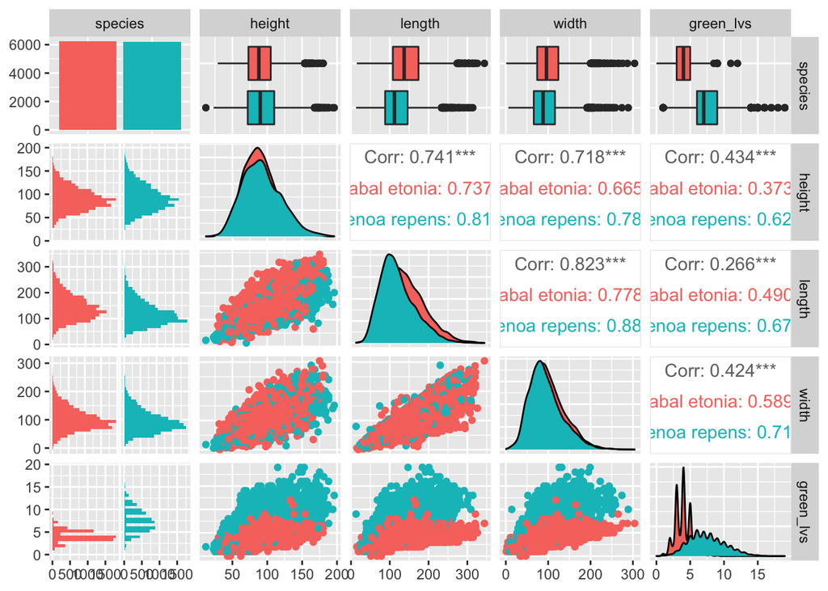

```r
palmetto$species <- gsub("1", "Serenoa repens", palmetto$species)
palmetto$species <- gsub("2", "Sabal etonia", palmetto$species)

palmetto$species <- as.factor(palmetto$species)

palmetto_explore <- palmetto

palmetto_explore %>%
  select(species, height:green_lvs) %>%
  ggpairs(aes(color = species))
```

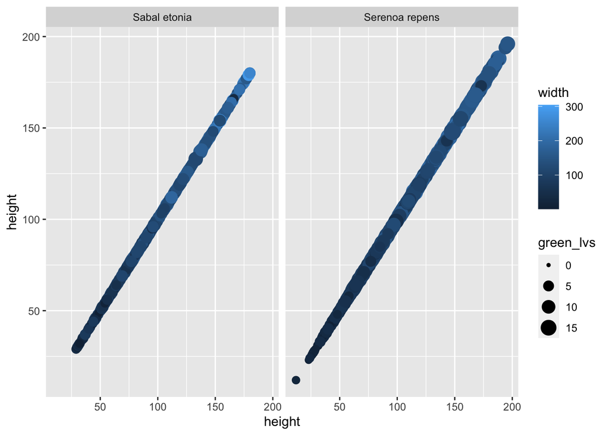

```r
ggplot(data = palmetto, aes(x = height, y = height)) +
  geom_point(aes(color = width,
                 size = green_lvs)) +
  facet_wrap(~species)
```

```r
palmetto_blr <- glm(species ~ height + length + width + green_lvs,
                            data = palmetto,
                            family = "binomial")
```

Look at the model:

```r
palmetto_blr
```

```
##
## Call:  glm(formula = species ~ height + length + width + green_lvs,
##     family = "binomial", data = palmetto)
##
## Coefficients:
## (Intercept)       height       length        width    green_lvs
##    -3.22669      0.02922     -0.04582     -0.03944      1.90847
##
## Degrees of Freedom: 12266 Total (i.e. Null);  12262 Residual
##   (193 observations deleted due to missingness)
## Null Deviance:       17010
## Residual Deviance: 5185  AIC: 5195
```

```r
summary(palmetto_blr)
```

```
##
## Call:
## glm(formula = species ~ height + length + width + green_lvs,
##     family = "binomial", data = palmetto)
##
## Deviance Residuals:
##     Min       1Q   Median       3Q      Max
## -4.7828  -0.2681  -0.0054   0.1725   3.3964
##
## Coefficients:
##              Estimate Std. Error z value Pr(>|z|)
## (Intercept) -3.226685   0.142071  -22.71   <2e-16 ***
## height       0.029217   0.002306   12.67   <2e-16 ***
## length      -0.045823   0.001866  -24.56   <2e-16 ***
## width       -0.039443   0.002100  -18.78   <2e-16 ***
## green_lvs    1.908475   0.038863   49.11   <2e-16 ***
## ---
## Signif. codes:  0 '***' 0.001 '**' 0.01 '*' 0.05 '.' 0.1 ' ' 1
##
## (Dispersion parameter for binomial family taken to be 1)
##
##     Null deviance: 17005.5  on 12266  degrees of freedom
## Residual deviance:  5184.6  on 12262  degrees of freedom
##   (193 observations deleted due to missingness)
## AIC: 5194.6
##
## Number of Fisher Scoring iterations: 7
```

```r
# Get a tidy version w/ broom:
palmetto_blr_tidy <- broom::tidy(palmetto_blr)
```

How can we start thinking about this?

Does this align with the height comparisons for the two species?

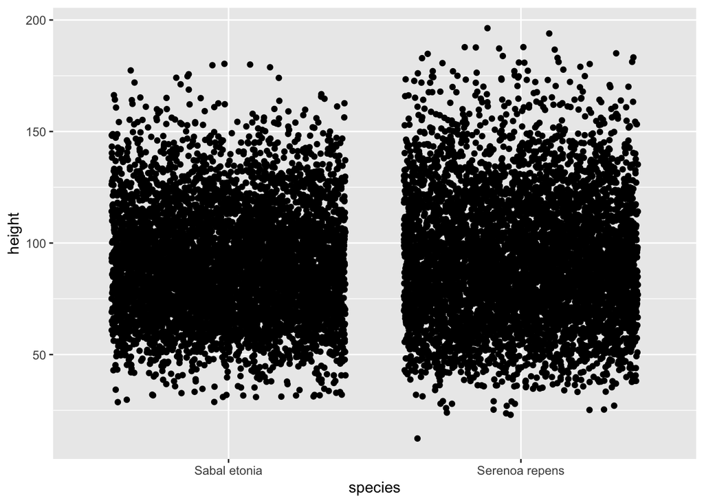

```r
ggplot(data = palmetto, aes(x = species, y = height)) +
  geom_jitter()
```

- The coefficient for length, -0.05, indicates that on average we expect the log odds of the species being a Serenoa repens decreases by -0.05 for each 1 mm increase in length (see `summary(palmetto_blr_tidy)` - this coefficient is significant).